# Chapter 7, Part II — Factor Analysis

**Factor analysis** is a statistical technique used to identify underlying factors or *latent variables* that explain patterns of correlations among observed variables. The primary goal of factor analysis is to reduce the number of observed variables by uncovering common underlying dimensions that account for most of the observed variance.

For example: Fisher (early 20th century) considered the following scenario:

- A group of students takes two tests:
  1. **French test**
  2. **English test**
- The scores are correlated: students who do well in French often do well in English.
- Fisher wondered: is there an **underlying ability** that explains this correlation?

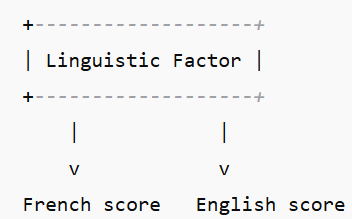

For example, in a test with several score variables, the underlying factors might represent *mathematical skills*, *programming skills*, etc. Suppose students take tests in **several subjects**:

| Variable | Description |
| --- | --- |
| Math | Arithmetic, Algebra, Calculus |
| Logic | Puzzles and reasoning tests |
| IQ | General reasoning and problem-solving |
| Reading | Comprehension and vocabulary tests |
| Writing | Essays, grammar |
| English | Language, literature, writing |
| Biology | Biology knowledge tests |
| History | History knowledge tests |
| Geography | Maps, physical geography |
| Art | Creativity and visual expression |

We notice that some tests are related:

- Math, Logic, IQ → analytical/quantitative ability
- Reading, Writing, English → verbal/language ability
- Biology, History, Geography → general knowledge / memorization ability
- Art → creativity / visual ability

This suggests there may be **several hidden abilities (factors)** underlying these observed tests.

We can hypothesize **four latent factors**:

1. **Quantitative/Analytical Ability** → Math, Logic, IQ
2. **Verbal/Linguistic Ability** → Reading, Writing, English
3. **General Knowledge** → Biology, History, Geography
4. **Creative/Artistic Ability** → Art

Each factor explains **why certain tests correlate**.

**Factor analysis** and **principal component analysis (PCA)** share similar objectives: both aim to summarize a set of variables using fewer dimensions to enhance understanding of interrelationships among them.

However, an important distinction exists:

- **PCA** is a data-reduction method that does not rely on a specific statistical model.
- **Factor analysis**, in contrast, is *model-based* and assumes that observed variables are influenced by latent factors plus random error.

## Factor Analysis Model

Each observed variable is modeled as a linear combination of *m* common factors plus a unique error term:

$$ \begin{aligned} X_1 &= \mu_1 + l_{11}f_1 + l_{12}f_2 + \dots + l_{1m}f_m + \epsilon_1 \\ X_2 &= \mu_2 + l_{21}f_1 + l_{22}f_2 + \dots + l_{2m}f_m + \epsilon_2 \\ &\ \vdots \\ X_p &= \mu_p + l_{p1}f_1 + l_{p2}f_2 + \dots + l_{pm}f_m + \epsilon_p \end{aligned} $$

where

- $X_1, X_2, \dots, X_p$ are the observed variables,
- $f_1, f_2, \dots, f_m$ are the common factors, and
- $\epsilon_1, \epsilon_2, \dots, \epsilon_p$ are random errors (unique factors).

In matrix form:

$$ \mathbf{X} - \mathbf{\mu} = \mathbf{L}\mathbf{f} + \mathbf{\epsilon} $$

or explicitly,

$$ \mathbf{X} - \mathbf{\mu} = \begin{pmatrix} l_{11}f_1 + l_{12}f_2 + \dots + l_{1m}f_m \\ \vdots \\ l_{p1}f_1 + l_{p2}f_2 + \dots + l_{pm}f_m \end{pmatrix} + \begin{pmatrix} \epsilon_1 \\ \vdots \\ \epsilon_p \end{pmatrix} $$

## Assumptions of Factor Analysis

1. **Linearity**: Relationships among variables are linear.
2. **Sufficient correlations**: There must be meaningful correlations among observed variables.
3. **Continuous variables**: Variables should ideally be continuous or approximately so.
4. **Multivariate normality**: For maximum likelihood estimation, variables are assumed multivariate normal.
5. **No multicollinearity**: Variables should not be perfectly correlated.
6. **Sample size**: A common rule of thumb — at least 5 to 10 observations per variable, and total $n \geq 100$.

## Factor Loadings

The **factor loadings** ($l_{ij}$) represent the extent to which each factor explains a given variable.

- Loadings close to ±1 indicate a *strong relationship* between the variable and the factor.
- Loadings close to 0 indicate a *weak relationship*.

**Commonly used thresholds:**  
Researchers often use a loading of **0.3 or 0.4** as the minimum level of significance. Loadings above **0.5** or **0.6** are typically considered substantial.

| Factor Loading | Approx. Sample Size Needed for Significance |
| --- | --- |
| 0.30 | 350 |
| 0.35 | 250 |
| 0.40 | 200 |
| 0.45 | 150 |
| 0.50 | 120 |
| 0.55 | 100 |
| 0.60 | 85 |
| 0.65 | 70 |
| 0.70 | 60 |
| 0.75 | 50 |

## Covariance Structure

The variance–covariance matrix of $\mathbf{X}$ is derived as:

$$ \begin{aligned} \text{Var}(\mathbf{X}) = \mathbf{\Sigma} &= \text{Var}(\mathbf{L}\mathbf{f} + \mathbf{\epsilon}) \\ &= \text{Var}(\mathbf{L}\mathbf{f}) + \text{Var}(\mathbf{\epsilon}) \\ &= \mathbf{L} \, \text{Cov}(\mathbf{f}) \, \mathbf{L}' + \mathbf{\Psi} \\ &= \mathbf{L}\mathbf{L}' + \mathbf{\Psi} \end{aligned} $$

## Communality and Specific Variance

The variance of the $i$-th variable is:

$$ \text{Var}(X_i) = \sum_{k=1}^m l_{ik}^2 + \psi_i $$

where

- $\sum_{k=1}^m l_{ik}^2$ : **Communality** — the portion of variance of variable $i$ explained by the common factors.
- $\psi_i$ : **Specific variance (uniqueness)** — the portion of variance unique to variable $i$, not explained by the factors.

For standardized data:

$$ \text{Communality} = \sum_{k=1}^m l_{ik}^2, \quad \text{Uniqueness} = 1 - \sum_{k=1}^m l_{ik}^2 $$

## Methods of Factor Extraction

There are several methods for estimating factor loadings ($\mathbf{L}$):

1. **Principal Factor Method (Principal Axis Factoring)**
   - Starts with the reduced correlation matrix (diagonal elements = communality estimates).
   - Iteratively updates communalities until convergence.
2. **Maximum Likelihood (ML) Method**
   - Assumes multivariate normality.
   - Estimates parameters by maximizing the likelihood function.
   - Allows for hypothesis testing (e.g., number of factors).
3. **Image Factor Method**
   - Based on multiple correlation coefficients and the image covariance matrix.

## Rotation of Factors

Rotation simplifies factor interpretation by producing a clearer pattern of loadings.

- **Orthogonal rotation (uncorrelated factors):**
  - *Varimax*: Maximizes variance of squared loadings across factors.
  - *Quartimax*: Simplifies variables (each variable loads highly on one factor).
  - *Equamax*: Combination of Varimax and Quartimax.
- **Oblique rotation (correlated factors):**
  - *Promax*, *Oblimin*: Allow factors to be correlated; more realistic for social sciences.

Rotation changes factor loadings but **not** the underlying model fit.

## Determining the Number of Factors

Several methods are used to decide how many factors to retain:

1. **Eigenvalues > 1 rule (Kaiser criterion):**  
   Retain factors with eigenvalues greater than 1.
2. **Scree plot:**  
   Plot eigenvalues and look for the “elbow” where the curve flattens.
3. **Cumulative variance explained:**  
   Retain enough factors to explain ~70–80% of total variance.
4. **Parallel analysis:**  
   Compare observed eigenvalues to those from random data.